# Determining text data relation to Hip-Hop artist lyrics

Benito Sanchez, Sammuel Villavicencio, Martin Almaraz

May 12, 2017

In 2013, Robert Galbraith published the novel The Cuckoo’s Calling. It was later discovered through linguistic analysis that Robert Galbraith was just a pen name used by JK Rowling, the author of Harry Potter. This analysis flows through a similar vein. We sought to predict the artist of a song based on the form of their lyrics.

The data was aquired from: https://www.kaggle.com/gyani95/380000-lyrics-from-metrolyrics

## Data Acquisition

```r
> # read csv
> data = read.csv("lyrics.csv", stringsAsFactors = F)
> library("caret")
```

```r
> library("stringr")
> library(rpart)
> library(rpart.plot)
>
> # the data seems to be very large at first...
> nrow(data)
```

```
[1] 339277
```

```r
> # but it includes many collums that we do not need, and genres we do not care for
> names(data)
```

```
[1] "index"  "song"   "year"   "artist" "genre"  "lyrics"
```

## Preprocessing and data munging

We decided to focus on the two hip-hop artists with the most lyrics.

```r
> # remove index, year, genre, and X as they will not help us
> # since our data includes many genres of music, we will need to remove anything but Hip-Hop
> data = data[data$genre == "Hip-Hop",]
>
> # remove any unessesary columns in the dataframe
> data$index = NULL
> data$year = NULL
> data$genre = NULL
> data$X = NULL
> data$song = NULL
>
> # remove all but top two artists
> top = names(head(sort(table(data$artist), decreasing=TRUE), 2))
> artists = data$artist
> data = data[is.element(artists, top),]
> data = data[!(data$lyrics == ''),]
```

## Create helper functions for sorting and generating features from our data

The features we selected include the number of words per song, the number of commas per song, the number of unique words per song, the number of lines per song and the number of words per line.

We created functions to calculate these features and bind them to the dataframe.

```r
> # get number of words per lyric
> get_num_words_in_lyric = function(lyric) {
+     return(sapply(gregexpr("\\W+", lyric), length) + 1)
+ }
>
> # get number of commas per song
> get_num_of_commas = function(lyric) {
+     return (str_count(lyric, ','))
+ }
>
> get_words = function(words)
+ {
+     words = scan(text = words, what='character', quote='')
+     words = gsub('[^a-zA-Z]*', '', words)
+     words = tolower(words)
+     words = words[!(words == '')]
+ }
>
> # number of unique words used per song
> get_num_unique_words = function(lyric) {
+     return(length(table(get_words(lyric))))
+ }
>
> # get number of lines per song
> get_num_lines = function(lyric) {
+     return(str_count(lyric, '\n') + 1)
+ }
>
> # get number of words per line per song
> get_words_per_line = function(lyric) {
+     return(mean(sapply(unlist(strsplit(lyric, '\n', fixed=TRUE)), get_num_words_in_lyric)))
+ }
>
> # add these new features to our data frame
> create_data = function(data) {
+     data$words_line = sapply(data[,"lyrics"], get_words_per_line)
+     data$num_lines = sapply(data[,"lyrics"], get_num_lines)
+     data$num_unique = sapply(data[,"lyrics"], get_num_unique_words)
+     data$num_commas = sapply(data[,"lyrics"], get_num_of_commas)
+     data$num_words_total = sapply(data[,"lyrics"], get_num_words_in_lyric)
+     data$lyrics = NULL
+     return(data)
+ }
>
> data = create_data(data)
```

### Data Exploration

We compare different aspects of these two artists such as shear amount of data that we have on each. This is vital in creating accurate models and features in that we have more data to train and test with.

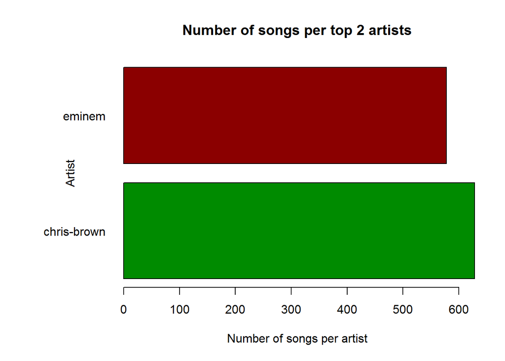

```r
>   par(mar=c(5.1, max(4.1, max(nchar(names(data)))/1.8), 4.1, 2.1))
>   barplot(head(sort(table(data$artist), decreasing = T), 2), horiz = T, las = 1, xlab = "Number of songs per artist", ylab = "Artist", col = c("green4", "red4", "blue4", "orange4"), main = "Number of songs per top 2 artists")
```